# Логистическя регрессия

Июль 7-8, 2018

Настройка глобальных опций отчёта:

```r
library(tidyverse) # обработка данных, графики...
library(skimr) # описательные статистики
library(rio) # импорт фантастического количества форматов данных
library(broom) # метла превращает результаты оценивания моделей в таблички
library(Ecdat) # много-много разных наборов данных
library(ISLR) # ещё данные
library(sandwich) # оценка Var для гетероскедастичности
library(caret) # пакет для подбора параметров разных моделей
library(FFTrees) # быстрые деревья
library(margins) # для подсчёта предельных эффектов
library(rpart.plot) # для картинок деревьев
library(plotROC) # визуализация ROC-кривой
library(ggeffects) # графики для предельных эффектов
library(MLmetrics) # метрики качества
```

Импортируем набор данных по респондентам и посмотрим на него :)

```r
ob <- import('C:/Users/ASUS/Desktop/r_course/data/obsl_1.sav')
skim(ob)
```

```
## Skim summary statistics
##  n obs: 1396
##  n variables: 11
##
## -- Variable type:numeric --------------------------------------------------------------------------------
##  variable missing complete    n      mean       sd       p0      p25
##    CHLICN       0     1396 1396      2.3      0.95     1        2
##    DOXODN       0     1396 1396  70931.52 45144.33 15844.74 46575.06
##   DOXODSN       0     1396 1396 151471.15 90155.63 17435.25 98033.05
##    FINPOL       0     1396 1396      3.17     0.69     1        3
##     NALOG       0     1396 1396  19234.86 13516.97     0    10660
##    NEPROD       0     1396 1396  42564.01 56420.06  1659.6  15937.23
##      OBPL       0     1396 1396     51.33    14.93    26       41
##    POTRAS       0     1396 1396 125436.12 81521.95 17435.25 80748.74
##      PROD       0     1396 1396  41036.27 19477.62  2483.84 27672.62
##       RPC       0     1396 1396      0.66     0.47     0        0
##     USLUG       0     1396 1396  34100.01 21893.3   1100    20304.39
##        p50       p75       p100     hist
##       2         3          6    ▅▇▁▆▂▁▁▁
##   60143.09  81619.72  634293.01 ▇▁▁▁▁▁▁▁
##  135823.27 178476.86  831987.19 ▆▇▂▁▁▁▁▁
##       3         4          5    ▁▂▁▇▁▃▁▁
##   17550     25755     105300    ▆▇▃▁▁▁▁▁
##   31607.72  52113    1200258    ▇▁▁▁▁▁▁▁
##      50        59        139    ▅▇▅▂▁▁▁▁
##  110650.66 151519.05 1451012.47 ▇▁▁▁▁▁▁▁
##   37228.33  49868.47   2e+05    ▃▇▂▁▁▁▁▁
##       1         1          1    ▅▁▁▁▁▁▁▇
##   30218.01  41543.95  242600.46 ▇▆▁▁▁▁▁▁
```

```r
glimpse(ob)
```

```
## Observations: 1,396
## Variables: 11
## $ CHLICN  <dbl> 2, 1, 4, 3, 2, 2, 2, 1, 1, 2, 2, 2, 3, 2, 2, 2, 1, 2, ...
## $ DOXODSN <dbl> 177670.07, 141512.22, 199999.26, 169907.29, 141838.19,...
## $ DOXODN  <dbl> 88835.04, 141512.22, 49999.82, 56635.76, 70919.10, 723...
## $ POTRAS  <dbl> 112010.07, 124712.22, 151272.73, 112667.29, 86268.44, ...
## $ PROD    <dbl> 55786.34, 34562.61, 60593.75, 63706.76, 56668.96, 4922...
## $ NEPROD  <dbl> 33969.00, 39434.83, 40214.55, 10455.00, 11635.26, 1705...
## $ USLUG   <dbl> 21841.41, 19564.96, 30751.43, 13700.00, 17964.22, 3176...
## $ NALOG   <dbl> 15660.00, 11700.00, 26226.53, 6240.00, 10469.75, 11700...
## $ OBPL    <dbl> 92, 34, 73, 92, 53, 73, 53, 73, 37, 73, 76, 34, 53, 73...
## $ RPC     <dbl> 1, 0, 1, 1, 1, 1, 1, 1, 0, 1, 1, 1, 1, 1, 0, 0, 0, 0, ...
## $ FINPOL  <dbl> 3, 3, 4, 3, 3, 4, 3, 4, 3, 4, 3, 4, 4, 3, 3, 3, 2, 3, ...
```

Целевая переменная — Наличие персонального компьютера RPC (1-да, 0 – нет) Остальные переменные — характеристики финансового положения респондента и условий его проживания.

Объявим качественные переменные факторными

```r
ob_fct <-ob %>%
 mutate_at(vars(FINPOL, RPC), factor)
```

Прологарифмируем основные денежные показатели

```r
ob$lnDOXODSN <- log(ob$DOXODSN)
```

```r
ob$lnUSLUG <- log(ob$USLUG)
```

```r
ob$lnNALOG <- log(ob$NALOG)
```

```r
ob$lnOBPL <- log(ob$OBPL)
```

```r
skim(ob)
```

```
## Skim summary statistics
##  n obs: 1396
##  n variables: 15
##
## -- Variable type:numeric --------------------------------------------------------------------------------
##   variable missing complete    n      mean       sd       p0      p25
##     CHLICN       0     1396 1396      2.3      0.95     1        2
##     DOXODN       0     1396 1396  70931.52 45144.33 15844.74 46575.06
##    DOXODSN       0     1396 1396 151471.15 90155.63 17435.25 98033.05
##     FINPOL       0     1396 1396      3.17     0.69     1        3
##  lnDOXODSN       0     1396 1396     11.79     0.53     9.77    11.49
##    lnNALOG       0     1396 1396   -Inf      NaN     -Inf        9.27
##     lnOBPL       0     1396 1396      3.9      0.27     3.26     3.71
##    lnUSLUG       0     1396 1396     10.28     0.57     7        9.92
##      NALOG       0     1396 1396  19234.86 13516.97     0    10660
##     NEPROD       0     1396 1396  42564.01 56420.06  1659.6  15937.23
##       OBPL       0     1396 1396     51.33    14.93    26       41
##     POTRAS       0     1396 1396 125436.12 81521.95 17435.25 80748.74
##       PROD       0     1396 1396  41036.27 19477.62  2483.84 27672.62
##        RPC       0     1396 1396      0.66     0.47     0        0
##      USLUG       0     1396 1396  34100.01 21893.3   1100    20304.39
##        p50       p75       p100     hist
##       2         3          6    ▅▇▁▆▂▁▁▁
##   60143.09  81619.72  634293.01 ▇▁▁▁▁▁▁▁
##  135823.27 178476.86  831987.19 ▆▇▂▁▁▁▁▁
##       3         4          5    ▁▂▁▇▁▃▁▁
##      11.82     12.09      13.63 ▁▁▂▅▇▃▁▁
##       9.77     10.16      11.56 ▁▁▁▂▆▇▃▁
##       3.91      4.08       4.93 ▂▃▆▇▃▁▁▁
##      10.32     10.63      12.4  ▁▁▁▃▇▇▂▁
##   17550     25755     105300    ▆▇▃▁▁▁▁▁
##   31607.72  52113    1200258    ▇▁▁▁▁▁▁▁
##      50        59        139    ▅▇▅▂▁▁▁▁
##  110650.66 151519.05 1451012.47 ▇▁▁▁▁▁▁▁
##   37228.33  49868.47   2e+05    ▃▇▂▁▁▁▁▁
##       1         1          1    ▅▁▁▁▁▁▁▇
##   30218.01  41543.95  242600.46 ▇▆▁▁▁▁▁▁
```

```r
glimpse(ob)
```

```
## Observations: 1,396
## Variables: 15
## $ CHLICN    <dbl> 2, 1, 4, 3, 2, 2, 2, 1, 1, 2, 2, 2, 3, 2, 2, 2, 1, 2...
## $ DOXODSN   <dbl> 177670.07, 141512.22, 199999.26, 169907.29, 141838.1...
## $ DOXODN    <dbl> 88835.04, 141512.22, 49999.82, 56635.76, 70919.10, 7...
## $ POTRAS    <dbl> 112010.07, 124712.22, 151272.73, 112667.29, 86268.44...
## $ PROD      <dbl> 55786.34, 34562.61, 60593.75, 63706.76, 56668.96, 49...
## $ NEPROD    <dbl> 33969.00, 39434.83, 40214.55, 10455.00, 11635.26, 17...
## $ USLUG     <dbl> 21841.41, 19564.96, 30751.43, 13700.00, 17964.22, 31...
## $ NALOG     <dbl> 15660.00, 11700.00, 26226.53, 6240.00, 10469.75, 117...
## $ OBPL      <dbl> 92, 34, 73, 92, 53, 73, 53, 73, 37, 73, 76, 34, 53, ...
## $ RPC       <dbl> 1, 0, 1, 1, 1, 1, 1, 1, 0, 1, 1, 1, 1, 1, 0, 0, 0, 0...
## $ FINPOL    <dbl> 3, 3, 4, 3, 3, 4, 3, 4, 3, 4, 3, 4, 4, 3, 3, 3, 2, 3...
## $ lnDOXODSN <dbl> 12.087684, 11.860141, 12.206069, 12.043008, 11.86244...
## $ lnUSLUG   <dbl> 9.991563, 9.881495, 10.333692, 9.525151, 9.796137, 1...
## $ lnNALOG   <dbl> 9.658865, 9.367344, 10.174527, 8.738735, 9.256245, 9...
## $ lnOBPL    <dbl> 4.521789, 3.526361, 4.290459, 4.521789, 3.970292, 4....
```

Разделим выборку на две части, обучающую и тестовую. По тестовой мы сможем оценить качество прогнозов нашей модели.

Разбиение выборки на две части — это случаная операция, поэтому зададим на удачу зерно генератора случайных чисел.

Создадим вектор `train_rows` с номерами строк для обучающей части.

```r
set.seed(777)
train_rows <- createDataPartition(ob_fct$RPC, p = 0.8, list = FALSE)
train_rows
```

```
##         Resample1
##    [1,]         1
##    [2,]         2
##    [3,]         3
##    [4,]         4
##    [5,]         6
##    [6,]         7
##    [7,]         8
##    [8,]         9
##    [9,]        10
##   [10,]        11
##   [11,]        12
##   [12,]        13
##   [13,]        15
##   [14,]        16
```

[output cut: 1104 more lines]

Разделим выборку согласно вектору `train_rows`:

```r
ob_train <- ob_fct[train_rows, ]
ob_test <- ob_fct[-train_rows, ]
glimpse(ob_fct)
```

```
## Observations: 1,396
## Variables: 11
## $ CHLICN  <dbl> 2, 1, 4, 3, 2, 2, 2, 1, 1, 2, 2, 2, 3, 2, 2, 2, 1, 2, ...
## $ DOXODSN <dbl> 177670.07, 141512.22, 199999.26, 169907.29, 141838.19,...
## $ DOXODN  <dbl> 88835.04, 141512.22, 49999.82, 56635.76, 70919.10, 723...
## $ POTRAS  <dbl> 112010.07, 124712.22, 151272.73, 112667.29, 86268.44, ...
## $ PROD    <dbl> 55786.34, 34562.61, 60593.75, 63706.76, 56668.96, 4922...
## $ NEPROD  <dbl> 33969.00, 39434.83, 40214.55, 10455.00, 11635.26, 1705...
## $ USLUG   <dbl> 21841.41, 19564.96, 30751.43, 13700.00, 17964.22, 3176...
## $ NALOG   <dbl> 15660.00, 11700.00, 26226.53, 6240.00, 10469.75, 11700...
## $ OBPL    <dbl> 92, 34, 73, 92, 53, 73, 53, 73, 37, 73, 76, 34, 53, 73...
## $ RPC     <fct> 1, 0, 1, 1, 1, 1, 1, 1, 0, 1, 1, 1, 1, 1, 0, 0, 0, 0, ...
## $ FINPOL  <fct> 3, 3, 4, 3, 3, 4, 3, 4, 3, 4, 3, 4, 4, 3, 3, 3, 2, 3, ...
```

# 1 Логистическая регрессия

С помощью метода максимального правдоподобия оценивается модель

$$y_i =
\begin{cases}
1, \text{ если } y^*_i \geq 0; \\
0, \text{ иначе.}
\end{cases}$$

$$y_i^* = \beta_1 + \beta_2 x_i + \beta_3 z_i + u_i,$$
где $u_i$ имеет специальное логистическое распределение.

Также модель можно записать в виде:

$$\frac{\ln P(y_i = 1)}{\ln P(y_i = 0)} = \beta_1 + \beta_2 x_i + \beta_3 z_i$$

1

```r
ob_lmodel_glm <- glm(data = ob_train, RPC ~ DOXODSN + USLUG + NALOG + OBPL + POTRAS, family = binomial(link = 'logit'))
summary(ob_lmodel_glm)
```

```
##
## Call:
## glm(formula = RPC ~ DOXODSN + USLUG + NALOG + OBPL + POTRAS,
##     family = binomial(link = "logit"), data = ob_train)
##
## Deviance Residuals:
##     Min       1Q   Median       3Q      Max
## -3.7654  -0.7874   0.4084   0.8012   1.9506
##
## Coefficients:
##               Estimate Std. Error z value Pr(>|z|)
## (Intercept) -3.050e+00  3.250e-01  -9.384  < 2e-16 ***
## DOXODSN      2.341e-06  3.995e-06   0.586 0.558008
## USLUG        7.738e-06  7.457e-06   1.038 0.299439
## NALOG        5.675e-05  1.084e-05   5.234 1.66e-07 ***
## OBPL         2.159e-02  5.622e-03   3.840 0.000123 ***
## POTRAS       1.064e-05  4.555e-06   2.336 0.019486 *
## ---
## Signif. codes:  0 '***' 0.001 '**' 0.01 '*' 0.05 '.' 0.1 ' ' 1
##
## (Dispersion parameter for binomial family taken to be 1)
##
##     Null deviance: 1426.5  on 1117  degrees of freedom
## Residual deviance: 1094.3  on 1112  degrees of freedom
## AIC: 1106.3
##
## Number of Fisher Scoring iterations: 5
```

AIC: 1106.3. Все переменные кроме USLUG, DOXODSN значимые.

2. Исключим переменную DOXODSN и построим новую модель

```r
ob_lmodel_glm <- glm(data = ob_train, RPC ~ USLUG + NALOG + OBPL + POTRAS, family = binomial(link = 'logit'))
summary(ob_lmodel_glm)
```

```
##
## Call:
## glm(formula = RPC ~ USLUG + NALOG + OBPL + POTRAS, family = binomial(link = "logit"),
##     data = ob_train)
##
## Deviance Residuals:
##     Min       1Q   Median       3Q      Max
## -3.7610  -0.7901   0.4010   0.8041   1.9472
##
## Coefficients:
##               Estimate Std. Error z value Pr(>|z|)
## (Intercept) -3.038e+00  3.240e-01  -9.377  < 2e-16 ***
## USLUG        7.577e-06  7.439e-06   1.019 0.308397
## NALOG        5.986e-05  9.448e-06   6.337 2.35e-10 ***
## OBPL         2.167e-02  5.618e-03   3.858 0.000114 ***
## POTRAS       1.289e-05  2.517e-06   5.121 3.03e-07 ***
## ---
## Signif. codes:  0 '***' 0.001 '**' 0.01 '*' 0.05 '.' 0.1 ' ' 1
##
## (Dispersion parameter for binomial family taken to be 1)
##
##     Null deviance: 1426.5  on 1117  degrees of freedom
## Residual deviance: 1094.7  on 1113  degrees of freedom
## AIC: 1104.7
##
## Number of Fisher Scoring iterations: 5
```

3. Исключим переменную USLUG и построим новую модель

```r
ob_lmodel_glm <- glm(data = ob_train, RPC ~ NALOG + OBPL + POTRAS, family = binomial(link = 'logit'))
summary(ob_lmodel_glm)
```

```
##
## Call:
## glm(formula = RPC ~ NALOG + OBPL + POTRAS, family = binomial(link = "logit"),
##     data = ob_train)
##
## Deviance Residuals:
##     Min       1Q   Median       3Q      Max
## -3.5831  -0.7922   0.4094   0.8011   1.9746
##
## Coefficients:
##               Estimate Std. Error z value Pr(>|z|)
## (Intercept) -3.042e+00  3.238e-01  -9.395  < 2e-16 ***
## NALOG        6.203e-05  9.199e-06   6.743 1.56e-11 ***
## OBPL         2.249e-02  5.560e-03   4.046 5.21e-05 ***
## POTRAS       1.429e-05  2.139e-06   6.680 2.38e-11 ***
## ---
## Signif. codes:  0 '***' 0.001 '**' 0.01 '*' 0.05 '.' 0.1 ' ' 1
##
## (Dispersion parameter for binomial family taken to be 1)
##
##     Null deviance: 1426.5  on 1117  degrees of freedom
## Residual deviance: 1095.7  on 1114  degrees of freedom
## AIC: 1103.7
##
## Number of Fisher Scoring iterations: 5
```

Коэффициенты модели значимы на уровне значимости $\alpha = 0.01$? AIC: 1103.7, что немного ниже, чем у первой и второй моделей.

Лучше использовать третью модель

Чтобы найти предельные эффекты, воспользуемся функцией `margins` из одноимённого пакета. Выведем результаты командой `summary()`.

```r
ob_margins <- margins(ob_lmodel_glm)
summary(ob_margins)
```

```
##  factor    AME     SE      z      p  lower  upper
##   NALOG 0.0000 0.0000 7.3012 0.0000 0.0000 0.0000
##    OBPL 0.0037 0.0009 4.1601 0.0000 0.0019 0.0054
##  POTRAS 0.0000 0.0000 7.2146 0.0000 0.0000 0.0000
```

Все предельные эффекты значимые.

По умолчанию считается средний предельный эффект. Если нужно подсчитать предельный эффект для конкретного наблюдения, например, для среднего, то можно воспользоваться опцией `at`.

```r
pred_ob_vis <- ggpredict(ob_lmodel_glm, terms = c('DOXODSN', 'RPC'))
pred_ob_vis <- plot(pred_ob_vis)
```

Оценивать логистическую модель также можно с помощью пакета `caret`.

```r
ob_lmodel <- train(data = ob_train, RPC ~ NALOG + OBPL + POTRAS, family = binomial(link = 'logit'), method = 'glm')
summary(ob_lmodel)
```

```
##
## Call:
## NULL
##
## Deviance Residuals:
##     Min       1Q   Median       3Q      Max
## -3.5831  -0.7922   0.4094   0.8011   1.9746
##
## Coefficients:
##               Estimate Std. Error z value Pr(>|z|)
## (Intercept) -3.042e+00  3.238e-01  -9.395  < 2e-16 ***
## NALOG        6.203e-05  9.199e-06   6.743 1.56e-11 ***
## OBPL         2.249e-02  5.560e-03   4.046 5.21e-05 ***
## POTRAS       1.429e-05  2.139e-06   6.680 2.38e-11 ***
## ---
## Signif. codes:  0 '***' 0.001 '**' 0.01 '*' 0.05 '.' 0.1 ' ' 1
##
## (Dispersion parameter for binomial family taken to be 1)
##
##     Null deviance: 1426.5  on 1117  degrees of freedom
## Residual deviance: 1095.7  on 1114  degrees of freedom
## AIC: 1103.7
##
## Number of Fisher Scoring iterations: 5
```

В результате получили аналогичный результат.

Посторим прогнозы модели для тестовых данных `ob_test`. Для этого будем использовать функцию `predict`, которой передадим оценённую модель `ob_lmodel`. В переменной `ob_predz` уже будут лежать предсказанные классы. Чтобы получить их вероятности, нужно добавить аргумент `type = 'prob'`.

```r
ob_pred <- predict(ob_lmodel, newdata = ob_test)
head(ob_pred)
```

```
## [1] 1 1 0 1 1 1
## Levels: 0 1
```

```r
ob_prob <- predict(ob_lmodel, newdata = ob_test, type = 'prob')
head(ob_prob)
```

```
##            0         1
## 5  0.4918176 0.5081824
## 14 0.4011619 0.5988381
## 25 0.8765629 0.1234371
## 28 0.3133573 0.6866427
## 37 0.2216464 0.7783536
## 42 0.3385662 0.6614338
```

Посмотрим на матрицу ошибок чтобы узнать, насколько хорошую модель мы оценили. Для этого будем использовть функцию `confusionMatrix` из пакета `caret`. В качестве аргумента `data` нужно указать предсказанные значения, а в `reference` — правильные ответы.

```r
confusionMatrix(data = ob_pred, reference = ob_test$RPC)
```

```
## Confusion Matrix and Statistics
##
##           Reference
## Prediction   0   1
##          0  45  20
##          1  48 165
##
##                Accuracy : 0.7554
##                  95% CI : (0.7005, 0.8048)
##     No Information Rate : 0.6655
##     P-Value [Acc > NIR] : 0.0007146
##
##                   Kappa : 0.4062
##  Mcnemar's Test P-Value : 0.0010595
##
##             Sensitivity : 0.4839
##             Specificity : 0.8919
##          Pos Pred Value : 0.6923
##          Neg Pred Value : 0.7746
##              Prevalence : 0.3345
##          Detection Rate : 0.1619
##    Detection Prevalence : 0.2338
##       Balanced Accuracy : 0.6879
##
##        'Positive' Class : 0
##
```

В редсказании нулей ошибки существенно выше, чем в предсказании единиц.

ROC — это площадь под кривой, построенной в осях доли правильных положительных ответов и доли неправильных положительных ответов в зависимости от значения порога для попадания в положительный класс.

AUC — это площадь под кривой, построенной в осях точность-полнота. Точность — это доля объектов на самом деле принадлежащих к положительному классу среди всех объектов, которых модель отнесла к положительному классу.
$$precision = TP / (TP + FP)$$

А F-мера — это среднее гармоническое между точностью и полнотой.

```r
ob_test_set <- data.frame('0' = ob_prob$'0',
                        '1' = ob_prob$'1',
                        pred = ob_pred,
                        obs = ob_test$RPC)
glimpse(ob_test_set)
```

```
## Observations: 278
## Variables: 4
## $ X0   <dbl> 0.49181763, 0.40116194, 0.87656291, 0.31335733, 0.2216463...
## $ X1   <dbl> 0.5081824, 0.5988381, 0.1234371, 0.6866427, 0.7783536, 0....
## $ pred <fct> 1, 1, 0, 1, 1, 1, 1, 1, 1, 1, 1, 1, 1, 1, 1, 1, 1, 1, 1, ...
## $ obs  <fct> 1, 1, 0, 1, 0, 0, 1, 1, 1, 1, 1, 1, 1, 0, 0, 0, 1, 0, 1, ...
```

```r
prSummary(ob_test_set, lev = levels(ob_test_set$obs))
```

```
##       AUC Precision    Recall         F
##        NA 0.6923077 0.4838710 0.5696203
```

```r
ggplot(ob_test_set, aes(d = obs, m = '1')) +
  geom_roc(n.cuts = '0')
```

[output not shown]

```r
ob_test_set <- mutate(ob_test_set, RPC = ob_test$RPC)

ggplot(ob_test_set, aes(d = obs, m = '1', color = RPC)) +
  geom_roc(n.cuts = '0')
```

[output not shown]

```r
ggplot(ob_test_set, aes(d = obs, m = '1')) +
  geom_roc(n.cuts = 0)
```

[output not shown]

```r
ob_test_set <- mutate(ob_test_set, RPC = ob_test$RPC)

ggplot(ob_test_set, aes(d = obs, m = '1', color = RPC)) +
  geom_roc(n.cuts = 0)
```

[output not shown]

# 2 На природу, к деревьям и в лес!

Бинарные деревья очень легко интепретируются при приемлемом качестве прогнозов.

Алгоритмы построения дерева отличаются деталями:

- по какому критерию делить веточку на две?
- когда остановить процесс деления веточек?
- следует ли обрезать дерево после окончания деления?
- как обрабатывать пропущенные значений?

```r
tree_model <- train(RPC ~ .- DOXODSN, data = ob_test,
                      method = 'rpart2',
                      na.action = na.omit)
```

Картинка дерева:

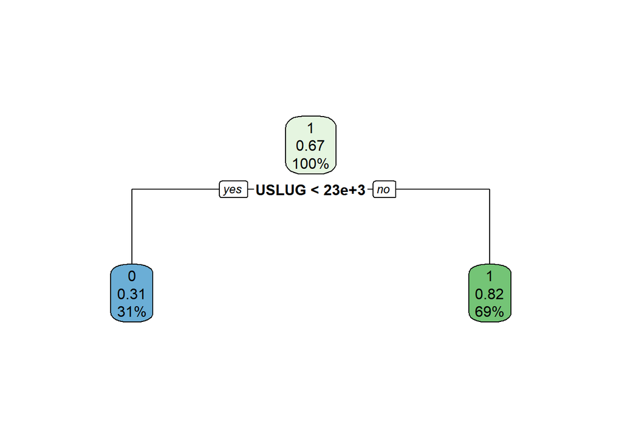

```r
rpart.plot(tree_model$finalModel)
```

Описание дерева:

```r
summary(tree_model)
```

[output not shown]

[output cut: 579 more lines]

```
##       NALOG  < 7396.15  to the left,  agree=0.827, adj=0.435, (0 split)
##       POTRAS < 71735.55 to the left,  agree=0.820, adj=0.412, (0 split)
##       CHLICN < 1.5      to the left,  agree=0.781, adj=0.282, (0 split)
##       NEPROD < 9542.5   to the left,  agree=0.763, adj=0.224, (0 split)
##       OBPL   < 41.5     to the left,  agree=0.737, adj=0.141, (0 split)
##
## Node number 2: 85 observations
##   predicted class=0  expected loss=0.3058824  P(node) =0.3057554
##     class counts:    59    26
##    probabilities: 0.694 0.306
##
## Node number 3: 193 observations
##   predicted class=1  expected loss=0.1761658  P(node) =0.6942446
##     class counts:    34   159
##    probabilities: 0.176 0.824
```

Предсказываем с помощью дерева на тестовой выборке:

```r
ob_tree <- mutate(ob_test,
  yhat = predict(tree_model, ob_test, na.action = na.pass))
confusionMatrix(ob_tree$yhat, ob_tree$RPC)
```

```
## Confusion Matrix and Statistics
##
##           Reference
## Prediction   0   1
##          0  59  26
##          1  34 159
##
##                Accuracy : 0.7842
##                  95% CI : (0.7311, 0.8311)
##     No Information Rate : 0.6655
##     P-Value [Acc > NIR] : 9.421e-06
##
##                   Kappa : 0.5047
##  Mcnemar's Test P-Value : 0.3662
##
##             Sensitivity : 0.6344
##             Specificity : 0.8595
##          Pos Pred Value : 0.6941
##          Neg Pred Value : 0.8238
##              Prevalence : 0.3345
##          Detection Rate : 0.2122
##    Detection Prevalence : 0.3058
##       Balanced Accuracy : 0.7469
##
##        'Positive' Class : 0
##
```

# 3 Случайный лес

В алгоритме случайного леса мы

1. Выращиваем целый лес, скажем 500, деревьев.
2. Строим прогноз с помощью каждого дерева.
3. Агрегируем прогнозы деревьев. Можно в качестве итогового прогноза выбрать ту категорию, за которую проголосовало большинство деревьев. Можно оценить вероятности категорий, взяв процент деревьев, проголосовавших за ту или иную категорию.

Деревья оказываются не идеальными копиями друг друга по двум причинам:

1. Каждое дерево обучается на случайной выборке из исходной выборки. Обычно для каждого дерева берут подвыборку с повторениями из исходной выборки, так чтобы размер подвыборки равнялся размеру исходной выборки.
2. При каждом делении каждой ветки на две части происходит предварительный случайный отбор переменных. Скажем, из исходных 100 переменных, каждый раз случайно отбирается 10, а затем из этих 10 выбирается наилучшая, по которой ветвь и делится на две ветви.

У идеи есть куча вариантов исполнения, отличающихся деталями:

- критерием деления ветви на две;
- критерием остановки деления дерева;
- количеством предварительно отбираемых переменных перед каждым делением;
- количество деревьев;

Посмотрим на все вариации случайного леса, которые перебрал `ranger`.

```r
ranger_model <- train(RPC ~ .- DOXODSN, data = ob_test,
                    method = 'ranger',
                    na.action = na.omit,
                    importance = 'impurity')
ranger_model
```

```
## Random Forest
##
## 278 samples
##  10 predictor
##   2 classes: '0', '1'
##
## No pre-processing
## Resampling: Bootstrapped (25 reps)
## Summary of sample sizes: 278, 278, 278, 278, 278, 278, ...
## Resampling results across tuning parameters:
##
##   mtry  splitrule   Accuracy   Kappa
##    2    gini        0.7879822  0.4961976
##    2    extratrees  0.7679974  0.4352416
##    7    gini        0.7769782  0.4770845
##    7    extratrees  0.7698601  0.4602907
##   12    gini        0.7658323  0.4560593
##   12    extratrees  0.7747169  0.4742288
##
## Tuning parameter 'min.node.size' was held constant at a value of 1
## Accuracy was used to select the optimal model using the largest value.
## The final values used for the model were mtry = 2, splitrule = gini
##  and min.node.size = 1.
```

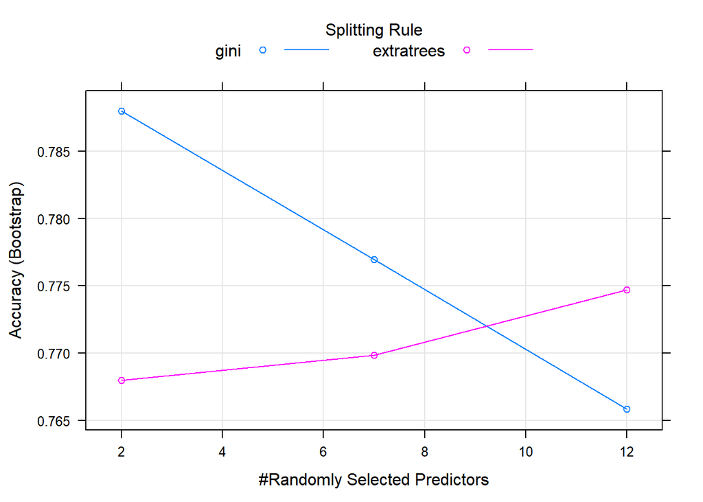

```r
plot(ranger_model)
```

И более подробно про наилучшую:

```r
ranger_model$finalModel
```

```
## Ranger result
##
## Call:
##  ranger::ranger(dependent.variable.name = ".outcome", data = x,      mtry = param$mtry, min.node.size = param$min.node.size, splitrule = as.character(param$splitrule),      write.forest = TRUE, probability = classProbs, ...)
##
## Type:                             Classification
## Number of trees:                  500
## Sample size:                      278
## Number of independent variables:  12
## Mtry:                             2
## Target node size:                 1
## Variable importance mode:         impurity
## Splitrule:                        gini
## OOB prediction error:             21.58 %
```

К сожалению, построить информативно про все сотни деревьев невозможно.

Можно попытаться выделить важность переменных:

```r
ranger_import <- varImp(ranger_model)
ranger_import
```

```
## ranger variable importance
##
##         Overall
## USLUG   100.000
## POTRAS   73.298
## NALOG    70.386
## PROD     57.449
## NEPROD   54.657
## DOXODN   45.858
## OBPL     44.663
## CHLICN   42.238
## FINPOL2  17.521
## FINPOL3   9.183
## FINPOL4   6.669
## FINPOL5   0.000
```

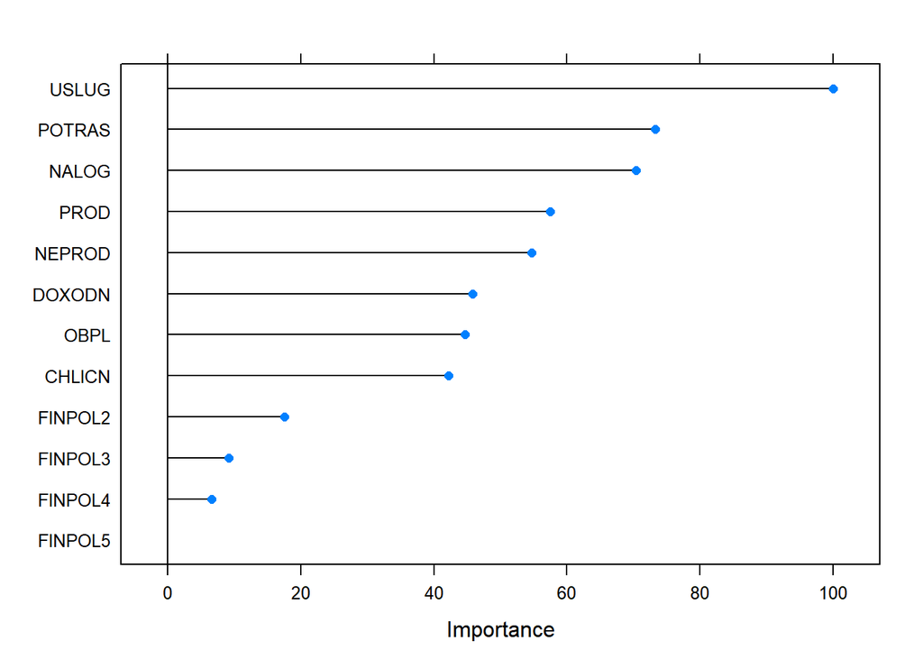

```r
plot(ranger_import)
```

И, конечно, построить прогнозы:

```r
ob_ranger <- mutate(ob_test,
  yhat = predict(ranger_model, ob_test, na.action = na.pass))
confusionMatrix(ob_ranger$yhat, ob_ranger$RPC)
```

```
## Confusion Matrix and Statistics
##
##           Reference
## Prediction   0   1
##          0  93   0
##          1   0 185
##
##                Accuracy : 1
##                  95% CI : (0.9868, 1)
##     No Information Rate : 0.6655
##     P-Value [Acc > NIR] : < 2.2e-16
##
##                   Kappa : 1
##  Mcnemar's Test P-Value : NA
##
##             Sensitivity : 1.0000
##             Specificity : 1.0000
##          Pos Pred Value : 1.0000
##          Neg Pred Value : 1.0000
##              Prevalence : 0.3345
##          Detection Rate : 0.3345
##    Detection Prevalence : 0.3345
##       Balanced Accuracy : 1.0000
##
##        'Positive' Class : 0
##
```

По умолчанию, пакет `caret` сам решает, сколько значений параметров перебирать и какие конкретно.

Список перебираемых параметров:

```r
modelLookup(model = 'ranger')
```

```
##    model     parameter                         label forReg forClass
## 1 ranger          mtry #Randomly Selected Predictors   TRUE     TRUE
## 2 ranger     splitrule                Splitting Rule   TRUE     TRUE
## 3 ranger min.node.size             Minimal Node Size   TRUE     TRUE
##   probModel
## 1      TRUE
## 2      TRUE
## 3      TRUE
```

Но мы можем заказать перебор любых.

Можно заказать количество перебираемых значений для каждого параметра:

```r
ranger_model <- train(RPC ~ ., data = ob_test,
                      method = "ranger",
                      na.action = na.omit,
                      importance = 'impurity',
                      tuneLength = 4)
```

Или явно значения

```r
grid <- expand.grid(mtry = c(5, 10), min.node.size = c(1, 5), splitrule = 'gini')

ranger_model <- train(RPC ~ ., data = ob_test,
            tuneGrid = grid, method = "ranger", na.action = na.omit)
ranger_model
```

```
## Random Forest
##
## 278 samples
##  10 predictor
##   2 classes: '0', '1'
##
## No pre-processing
## Resampling: Bootstrapped (25 reps)
## Summary of sample sizes: 278, 278, 278, 278, 278, 278, ...
## Resampling results across tuning parameters:
##
##   mtry  min.node.size  Accuracy   Kappa
##    5    1              0.7688751  0.4526526
##    5    5              0.7715967  0.4576976
##   10    1              0.7612093  0.4368817
##   10    5              0.7607594  0.4371427
##
## Tuning parameter 'splitrule' was held constant at a value of gini
## Accuracy was used to select the optimal model using the largest value.
## The final values used for the model were mtry = 5, splitrule = gini
##  and min.node.size = 5.
```

:)